# Multispecies Recruitment

Sarah Gaichas

26 January, 2022

## Evaluate change in recruitment over time for assessed species

### Get stocksmart info

Can we pull most recent recruitment and SSB or other B outputs from Northeast US stock assessments? Which species do we have? What units are recruitments in?

```r
NErec <- stocksmart::stockAssessmentData %>%
  filter(RegionalEcosystem == "Northeast Shelf",
         Metric == "Recruitment") %>%
  group_by(StockName) %>%
  filter(AssessmentYear == max(AssessmentYear)) %>%
  ungroup()

sppunits <- NErec %>%
  select(StockName, StockArea, Description, Units) %>%
  distinct()

datatable(sppunits, rownames = FALSE,
             options = list(scrollX = TRUE,
                            pageLength = 10))
```

| StockName | StockArea | Description | Units |
| --- | --- | --- | --- |
| Acadian redfish - Gulf of Maine / Georges Bank | Gulf of Maine / Georges Bank | Abundance - Age 1 (Mean) | Thousand Recruits |
| American plaice - Gulf of Maine / Georges Bank | Gulf of Maine / Georges Bank | Abundance - Age 1 | Thousand Recruits |
| Goosefish - Gulf of Maine / Northern Georges Bank | Gulf of Maine / Northern Georges Bank | Abundance, Age 1 | Number x 1,000,000 |
| Goosefish - Southern Georges Bank / Mid-Atlantic | Southern Georges Bank / Mid-Atlantic | Abundance, Age 1 | Number x 1,000,000 |
| Haddock - Eastern Georges Bank | Eastern Georges Bank | Abundance, Age 1 (Mean) | Number x 1,000 |
| Haddock - Georges Bank | Georges Bank | Abundance - Age 1 | Thousand Recruits |
| Haddock - Gulf of Maine | Gulf of Maine | Abundance - Age 1 | Thousand Recruits |
| Northern shortfin squid - Northwestern Atlantic Coast | Northwestern Atlantic Coast | Survey Abundance, ≤10cm, NEFSC Fall Survey (Delta Transformed) | Number/Tow |
| Ocean quahog - Atlantic Coast | Atlantic Coast | Recruitment / Unifished Recruitment | Ratio |
| Pollock - Gulf of Maine / Georges Bank | Gulf of Maine / Georges Bank | Abundance - Age 1 | Thousand Recruits |

[output cut: 25 more lines]

Lets check the units for biomass too.

```r
NEbio <- stocksmart::stockAssessmentData %>%
  filter(RegionalEcosystem == "Northeast Shelf",
         Metric == "Abundance") %>%
  group_by(StockName) %>%
  filter(AssessmentYear == max(AssessmentYear)) %>%
  ungroup()

sppunits <- NEbio %>%
  select(StockName, StockArea, Description, Units) %>%
  distinct()

datatable(sppunits, rownames = FALSE,
             options = list(scrollX = TRUE,
                            pageLength = 10))
```

| StockName | StockArea | Description | Units |
| --- | --- | --- | --- |
| Acadian redfish - Gulf of Maine / Georges Bank | Gulf of Maine / Georges Bank | Mature Biomass Retro Adjusted 2019 (Mean) | Metric Tons |
| American plaice - Gulf of Maine / Georges Bank | Gulf of Maine / Georges Bank | Retrospective Adjusted Spawning Stock Biomass | Metric Tons |
| Goosefish - Gulf of Maine / Northern Georges Bank | Gulf of Maine / Northern Georges Bank | Survey Estimated Area-Swept Biomass | Metric Tons |
| Goosefish - Southern Georges Bank / Mid-Atlantic | Southern Georges Bank / Mid-Atlantic | Survey Estimated Area-Swept Biomass | Metric Tons |
| Haddock - Eastern Georges Bank | Eastern Georges Bank | 2-Survey Biomass Estimate | Thousand Metric Tons |
| Haddock - Georges Bank | Georges Bank | Retrospective Adjusted Spawning Stock Biomass | Metric Tons |
| Haddock - Gulf of Maine | Gulf of Maine | Retrospective Adjusted Spawning Stock Biomass | Metric Tons |
| Little skate - Georges Bank / Southern New England | Georges Bank / Southern New England | 3-Year Average Survey CPUE | Kilograms / Tow |
| Longfin inshore squid - Georges Bank / Cape Hatteras | Georges Bank / Cape Hatteras | Two-year Moving Average of Annualized B (Avg. Fall and Spring Survey Biomass) | Thousand Metric Tons |
| Northern shortfin squid - Northwestern Atlantic Coast | Northwestern Atlantic Coast | Survey Biomass, NEFSC Fall Survey (Delta Transformed) | Kilograms/Tow |

[output cut: 40 more lines]

Select down to stocks used in SOE productivity anomaly indicator? Won’t split them by EPU but could map some stocks to different regions kinda. Or just pick MA managed stocks in stocksmart? Here just trying to get a list of stocks that have both recruitment and biomass in stocksmart. Weeding out recruitment measures that are not in numbers for now.

Also, lets not use assessments prior to 2019.

```r
# first pass only stocks with both rec in N and bio but keep all years of bio

NErecN <- NErec %>%
  filter(AssessmentYear>2018,
         Units %in% c("Thousand Recruits",
                      "Number x 1,000,000",
                      "Number x 1,000",
                      "Million Recruits"))

NErecstocks <- NErecN %>%
  select(StockName) %>%
  distinct()

NEbiohasrec <- NEbio %>%
  filter(StockName %in% NErecstocks$StockName)
```

Next steps:

Reconcile the units so inputs are the same across stocks

Units of recruitment in numbers of fish at age 1 is the input to the survey based productivity anomaly indicator. We’ll need to convert all to numbers and note the age of recruitment for each stock to shift recruitment appropriately.

```r
NErecNstd <- NErecN %>%
  mutate(NfishRec = case_when(Units == "Thousand Recruits" ~ Value*1000,
                              Units == "Number x 1,000,000" ~ Value*1000000,
                              Units == "Number x 1,000" ~ Value*1000,
                              Units == "Million Recruits" ~ Value*1000000,
                              TRUE ~ as.numeric(NA)),
         AgeRec = as.numeric(stringr::str_extract(Description, "(\\d)+")),
         SSByr = Year-AgeRec
         )
```

Plot each Rec series by SSByr

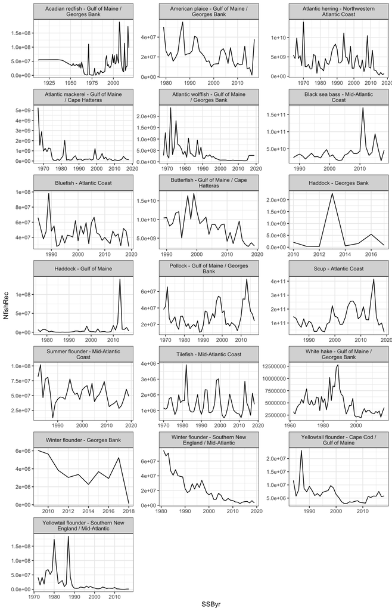

```r
ggplot(NErecNstd, aes(x=SSByr, y=NfishRec)) +
  geom_line() +
  theme_bw() +
  facet_wrap(~StockName, ncol = 3, scales = "free",
             labeller = labeller(StockName = label_wrap_gen(35)))
```

Units of biomass (all listed as mature/spawning stock or retro adjusted spawning stock) are converted to kg for similarity with survey anomaly code.

```r
NEbioBstd <- NEbiohasrec %>%
  mutate(SSBkg = case_when(Units == "Thousand Metric Tons" ~ Value*1000000,
                              Units == "Metric Tons" ~ Value*1000,
                              TRUE ~ as.numeric(NA))
         #AgeRec = as.numeric(stringr::str_extract(Description, "(\\d)+")),
         #SSByr = Year-AgeRec
         )
```

Plot each SSB series by Year

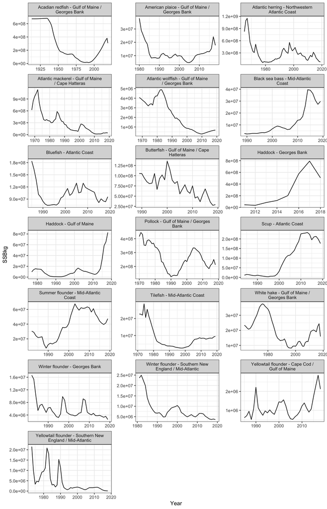

```r
ggplot(NEbioBstd, aes(x=Year, y=SSBkg)) +
  geom_line() +
  theme_bw() +
  facet_wrap(~StockName, ncol = 3, scales = "free",
             labeller = labeller(StockName = label_wrap_gen(35)))
```

### Do the Perretti anomaly calculation

For the survey data, this is in `trawlr` package `func-data.R`, function `calc_rec()` starting line 798.

Current SOE indicator using `rs_anom` output of this as input for plotting so need to calculate equivalent of that one.

Modify code to take `stocksmart` inputs converted to common units

This is `trawlr::calc_z` used in `calc_rec()`

```r
# ---------------------------------------------------------
#' Calculate z-score of vector
#'
#'
#' @param x vector of which to calculate z-score
#'
#' @param ... other params that can be fed to mean() or sd()
#'
#' @return vector of z-score values of x
#'
#' @examples
#'
#' x_zscore <- calc_z(x = c(1:10), na.rm = T)
#'
#' @export

calc_z <- function(x, ...) {
  (x - mean(x, ...))/sd(x, ...)
}
```

This is `trawlr::calc_rec()` full code.

```r
#' Calculate spawner-recruit anomalies
#'
#' Calculates a time series of spawner-recruit anomalies
#' (and other anomalies) for all species in survdat. Survdat
#' must have biological and epu data, so \emph{load_survdat()}
#' must have been called with \emph(with_bio_epu) = TRUE.
#'
#' @param survdat dataframe; from \emph{load_survdat()}
#'                called with \emph{with_bio_epu} = TRUE.
#'
#' @param min_year numeric value; minimum year to include
#'                 in the recruitment calculations.
#'
#' @param max_year numeric value; maximum year to include
#'                 in the recruitment calculations.
#'
#' @param by_epu logical; if TRUE recruitment variables are
#'               calculated per ecological production unit
#'               (EPU).
#'
#' @param by_taxon logical; if TRUE recruitment variables are
#'                 calculated per ecological production unit
#'                 (EPU).
#'
#'
#' @return dataframe with recruitment related variables.
#'
#' @examples
#' calc_rec(survdat = survdat,
#'          min_year = 1980, max_year = 2008,
#'          by_epu = TRUE, by_taxon = FALSE)
#'
#' @export
calc_rec <- function(survdat,
                     min_year,
                     max_year,
                     by_epu,
                     by_taxon,
                     by_season = FALSE,
                     len_cutoff = 0.2) {

  # Calculate the mean length at age-1 for species
  # with age data
  df_len_at_age1 <-
    survdat %>%
    dplyr::filter(YEAR >= (min_year - 1),
                  YEAR <= (max_year + 1),
                  !is.na(AGE),
                  !is.na(LENGTH)) %>%
    dplyr::group_by(COMNAME, SCINAME) %>%
    dplyr::do(fit_length_at_age1(AGE = .$AGE,
                                 LENGTH = .$LENGTH))



  # Calculate the number of tows in each survey season
  dat_tows <-
    survdat %>%
    dplyr::distinct(CRUISE6, YEAR, SEASON, STATION, STRATUM) %>%
    dplyr::select(CRUISE6, YEAR, SEASON) %>%
    dplyr::group_by(CRUISE6, YEAR, SEASON) %>%
    dplyr::summarise(n_tows = n())


  dat_spec_rec <-
    survdat %>%
    dplyr::left_join(dat_tows) %>%
    dplyr::left_join(df_len_at_age1) %>%
    dplyr::group_by(COMNAME, SCINAME) %>%
    dplyr::filter(EPU %in% c("MAB", "GB", "GOM")) %>%
    dplyr::filter(YEAR >= (min_year - 1),
                  YEAR <= (max_year + 1)) %>%
    #dplyr::do(trawlr::calc_lw(dat = .)) %>%
    dplyr::group_by(., COMNAME) %>%
    { if (by_epu) dplyr::group_by(., EPU, add = T) else . } %>%
    { if (by_taxon) dplyr::group_by(., order, add = T) else . } %>%
    { if (by_season) dplyr::group_by(., SEASON, add = T) else . } %>%
    dplyr::mutate(rank_LENGTH = dplyr::cume_dist(LENGTH),
                  NUMLEN      = as.numeric(NUMLEN),
                  INDWT       = as.numeric(INDWT),
                  WTperLENGTH = INDWT / LENGTH) %>%
    # Remove NA's
    dplyr::filter(!is.na(rank_LENGTH)) %>%
    # If length at age1 exists use it, else use the length
    # cutoff
    dplyr::mutate(maturity = ifelse(is.na(length_at_age1),
                                    ifelse(rank_LENGTH > len_cutoff,
                                           "spawner",
                                           "recruit"),
                                   ifelse(LENGTH > length_at_age1,
                                          "spawner",
                                          "recruit"))
                                        ) %>%
    dplyr::mutate(ind_sp_abund = ifelse(maturity == "spawner",
                                        NUMLEN,
                                        0),
                  ind_rec_abund = ifelse(maturity == "recruit",
                                         NUMLEN,
                                         0),
                  ind_sp_wl    = ifelse(maturity == "spawner",
                                        WTperLENGTH,
                                        NaN),
                 ind_rec_wl    = ifelse(maturity == "recruit",
                                        WTperLENGTH,
                                        NaN),
                 ind_sp_wl_res = ifelse(maturity == "spawner",
                                        (INDWT - INDWT_ALLPRED),
                                        NaN),
                 ind_rec_wl_res = ifelse(maturity == "recruit",
                                         (INDWT - INDWT_ALLPRED),
                                         NaN)) %>%
    { if (by_taxon == TRUE & by_epu == TRUE) {
        dplyr::group_by(., YEAR, SEASON,
                        SCINAME, COMNAME, EPU, order)
      } else if (by_epu == TRUE) {
        dplyr::group_by(., YEAR, SEASON,
                        SCINAME, COMNAME, EPU)
      } else {
        dplyr::group_by(., YEAR, SEASON,
                        SCINAME, COMNAME)
      }
    } %>%
    dplyr::summarise(n_tows = unique(n_tows),
                     spawners_abund = sum(ind_sp_abund, na.rm = T)/n_tows,
                     spawners_biom = sum(ind_sp_abund *
                                         INDWT_PRED, na.rm = T)/n_tows,
                     recruits_abund = sum(ind_rec_abund, na.rm = T)/n_tows,
                     recruits_biom = sum(ind_rec_abund *
                                         INDWT_PRED, na.rm = T)/n_tows,
                     spawner_wl   = mean(ind_sp_wl, na.rm = T),
                     recruit_wl   = mean(ind_rec_wl, na.rm = T),
                     spawner_wl_res = mean(ind_sp_wl_res,
                                           na.rm = T),
                     recruit_wl_res = mean(ind_rec_wl_res,
                                           na.rm = T)) %>%
    # Calculate log(R/S), log(R), log(S)
    dplyr::ungroup(.) %>%
    { if (by_taxon == TRUE & by_epu == TRUE) {
        dplyr::arrange(., SEASON,
                       COMNAME, SCINAME, EPU, order, YEAR) %>%
        dplyr::group_by(., SEASON,
                        COMNAME, SCINAME, EPU, order)
      } else if (by_epu == TRUE) {
        dplyr::arrange(., SEASON,
                       COMNAME, SCINAME, EPU, YEAR) %>%
        dplyr::group_by(., SEASON,
                        COMNAME, SCINAME, EPU)
      } else if (by_taxon == TRUE) {
        dplyr::arrange(., SEASON,
                       COMNAME, SCINAME, order, YEAR) %>%
        dplyr::group_by(., SEASON,
                        COMNAME, SCINAME, order)
      } else {
        dplyr::arrange(., SEASON,
                       COMNAME, SCINAME, YEAR) %>%
        dplyr::group_by(., SEASON,
                        COMNAME, SCINAME)
      }
    } %>%
    dplyr::mutate(recruits_biom_lead1 = dplyr::lead(recruits_biom,
                                                    n = 1),
                  recruits_abund_lead1 = dplyr::lead(recruits_abund,
                                                     n = 1),
                  rs         = recruits_abund_lead1/
                               spawners_biom,
                  rs_abund   = recruits_abund_lead1/
                                spawners_abund,
                  rs_biom    = recruits_biom_lead1/
                                spawners_biom,
                  logr_abund = log(recruits_abund_lead1),
                  logr_biom  = log(recruits_biom_lead1),
                  logs_abund = log(spawners_abund),
                  logs_biom  = log(spawners_biom),
                  logrs      = log(rs),
                  logrs_abund = log(rs_abund),
                  logrs_biom  = log(rs_biom),
                  spawners_abund_lag0_anom =
                    trawlr::calc_z(spawners_abund,
                                   na.rm = T),
                  spawners_biom_lag0_anom =
                    trawlr::calc_z(spawners_biom,
                                   na.rm = T),
                  recruits_abund_lead1_anom =
                    trawlr::calc_z(recruits_abund_lead1,
                                   na.rm = T),
                  recruits_biom_lead1_anom =
                    trawlr::calc_z(recruits_biom_lead1,
                                   na.rm = T),
                  rs_anom       = trawlr::calc_z(rs,
                                                na.rm = T),
                  rs_abund_anom = trawlr::calc_z(rs_abund,
                                                 na.rm = T),
                  rs_biom_anom = trawlr::calc_z(rs_biom,
                                                na.rm = T),
                  logr_abund_anom =
                    trawlr::calc_z(logr_abund),
                  logr_biom_anom =
                    trawlr::calc_z(logr_biom),
                  logs_abund_anom =
                    trawlr::calc_z(logs_abund, na.rm = T),
                  logs_biom_anom =
                    trawlr::calc_z(logs_biom, na.rm = T),
                  logrs_anom =
                    trawlr::calc_z(logrs, na.rm = T),
                  logrs_abund_anom =
                    trawlr::calc_z(logrs_abund, na.rm = T),
                  logrs_biom_anom =
                    trawlr::calc_z(logrs_biom, na.rm = T),
                  spawner_wl_anom  =
                    trawlr::calc_z(spawner_wl),
                  recruit_wl_lead1 = dplyr::lead(recruit_wl, n = 1),
                  recruit_wl_lead1_anom =
                    trawlr::calc_z(recruit_wl_lead1),
                  spawner_wl_res_anom =
                    trawlr::calc_z(spawner_wl_res),
                  recruit_wl_res_lead1 = dplyr::lag(recruit_wl_res, n = 1),
                  recruit_wl_res_lead1_anom =
                    trawlr::calc_z(recruit_wl_res_lead1)) %>%
    # Remove year before minimum and year after maximum
    dplyr::filter(YEAR >= min_year,
                  YEAR <= max_year) %>%
    #Average seasonal anomalies to get yearly anomaly
    dplyr::group_by(., YEAR, SCINAME, COMNAME) %>%
    { if (by_epu) dplyr::group_by(., EPU, add = T) else . } %>%
    { if (by_taxon) dplyr::group_by(., order, add = T) else . } %>%
    { if (by_season) dplyr::group_by(., SEASON, add = T) else . } %>%
    dplyr::summarise(
      spawners_abund_lag0 = mean(spawners_abund,
                                 na.rm = T),
      spawners_abund_lag0_anom = mean(spawners_abund_lag0_anom,
                                      na.rm = T),
      spawners_biom_lag0 = mean(spawners_biom, na.rm = T),
      spawners_biom_lag0_anom = mean(spawners_biom_lag0_anom,
                                     na.rm = T),
      recruits_abund    = mean(recruits_abund, na.rm = T),
      recruits_abund_lead1      = mean(recruits_abund_lead1,
                                        na.rm = T),
      recruits_abund_lead1_anom = mean(recruits_abund_lead1_anom,
                                        na.rm = T),
      recruits_biom_lead1      = mean(recruits_biom_lead1,
                                       na.rm = T),
      recruits_biom_lead1_anom  = mean(recruits_biom_lead1_anom,
                                        na.rm = T),
      rs                 = mean(rs, na.rm = T),
      rs_abund           = mean(rs_abund, na.rm = T),
      rs_biom            = mean(rs_biom, na.rm = T),
      rs_anom            = mean(rs_anom, na.rm = T),
      rs_abund_anom      = mean(rs_abund_anom, na.rm = T),
      rs_biom_anom       = mean(rs_biom_anom, na.rm = T),
      logr_abund_anom    = mean(logr_abund_anom,
                                na.rm = T),
      logr_biom_anom     = mean(logr_biom_anom,
                                na.rm = T),
      logs_abund_anom    = mean(logs_abund_anom,
                                na.rm = T),
      logs_biom_anom     = mean(logs_biom_anom,
                                na.rm = T),
      logrs_anom         = mean(logrs_anom, na.rm = T),
      logrs_abund_anom    = mean(logrs_abund_anom,
                                 na.rm = T),
      logrs_biom_anom     = mean(logrs_biom_anom,
                                 na.rm = T),
      spawner_wl_anom     = mean(spawner_wl_anom,
                                 na.rm = T),
      recruit_wl_lead1_anom = mean(recruit_wl_lead1_anom,
                                 na.rm = T),
```

```r
      spawner_wl_res_anom = mean(spawner_wl_res_anom,
                                 na.rm = T),
      recruit_wl_res_lead1_anom = mean(recruit_wl_res_lead1_anom,
                                       na.rm = T))

  return(dat_spec_rec)
}
```

This is the bit I’ve pulled out to use with the stock assessment recruitment and SSB series standardized above.

```r
# dataset with each species std rec in SSByr and SSB

SSrecbio <- NErecNstd %>%
  select(StockName, SSByr, NfishRec) %>%
  left_join(NEbioBstd, by = c("StockName" = "StockName",
                              "SSByr"="Year")) %>%
  select(StockName, SSByr, NfishRec, SSBkg)

min_year <- 1980
max_year <- 2020

dat_spec_rec <- SSrecbio %>%
  group_by(StockName) %>%
  dplyr::mutate(#recruits_biom_lead1 = dplyr::lead(recruits_biom,
                #                                    n = 1),
                  recruits_abund_lead1 = NfishRec, #dplyr::lead(recruits_abund,
                                                  #   n = 1),
                  spawners_biom = SSBkg,
                  YEAR = SSByr,
                  rs         = recruits_abund_lead1/
                               spawners_biom,
                  #rs_abund   = recruits_abund_lead1/
                  #              spawners_abund,
                  #rs_biom    = recruits_biom_lead1/
                  #              spawners_biom,
                  logr_abund = log(recruits_abund_lead1),
                  #logr_biom  = log(recruits_biom_lead1),
                  #logs_abund = log(spawners_abund),
                  logs_biom  = log(spawners_biom),
                  logrs      = log(rs),
                  #logrs_abund = log(rs_abund),
                  #logrs_biom  = log(rs_biom),
                  #spawners_abund_lag0_anom =
                  #  ''calc_z(spawners_abund,
                  #                 na.rm = T),
                  spawners_biom_lag0_anom =
                    calc_z(spawners_biom,
                                   na.rm = T),
                  recruits_abund_lead1_anom =
                    calc_z(recruits_abund_lead1,
                                   na.rm = T),
                  #recruits_biom_lead1_anom =
                  #  calc_z(recruits_biom_lead1,
                  #                 na.rm = T),
                  rs_anom       = calc_z(rs,
                                                na.rm = T),
                  #rs_abund_anom = calc_z(rs_abund,
                  #                               na.rm = T),
                  #rs_biom_anom = calc_z(rs_biom,
                  #                              na.rm = T),
                  logr_abund_anom =
                    calc_z(logr_abund),
                  #logr_biom_anom =
                  #  calc_z(logr_biom),
                  #logs_abund_anom =
                  #  calc_z(logs_abund, na.rm = T),
                  logs_biom_anom =
                    calc_z(logs_biom, na.rm = T),
                  logrs_anom =
                    calc_z(logrs, na.rm = T),
                  #logrs_abund_anom =
                  #  calc_z(logrs_abund, na.rm = T),
                  #logrs_biom_anom =
                  #  calc_z(logrs_biom, na.rm = T),
                  #spawner_wl_anom  =
                  #  calc_z(spawner_wl),
                  #recruit_wl_lead1 = dplyr::lead(recruit_wl, n = 1),
                  #recruit_wl_lead1_anom =
                  #  calc_z(recruit_wl_lead1),
                  #spawner_wl_res_anom =
                  #  calc_z(spawner_wl_res),
                  #recruit_wl_res_lead1 = dplyr::lag(recruit_wl_res, n = 1),
                  #recruit_wl_res_lead1_anom =
                  #  calc_z(recruit_wl_res_lead1)
                  ) %>%
    # Remove year before minimum and year after maximum
    dplyr::filter(YEAR >= min_year,
                  YEAR <= max_year) %>%
    #Average seasonal anomalies to get yearly anomaly
    dplyr::group_by(., YEAR, StockName) %>% #SCINAME, COMNAME) %>%
    # { if (by_epu) dplyr::group_by(., EPU, add = T) else . } %>%
    # { if (by_taxon) dplyr::group_by(., order, add = T) else . } %>%
    # { if (by_season) dplyr::group_by(., SEASON, add = T) else . } %>%
    dplyr::summarise(
      # spawners_abund_lag0 = mean(spawners_abund,
      #                            na.rm = T),
      # spawners_abund_lag0_anom = mean(spawners_abund_lag0_anom,
      #                                 na.rm = T),
      spawners_biom_lag0 = mean(spawners_biom, na.rm = T),
      spawners_biom_lag0_anom = mean(spawners_biom_lag0_anom,
                                     na.rm = T),
      #recruits_abund    = mean(recruits_abund, na.rm = T),
      recruits_abund_lead1      = mean(recruits_abund_lead1,
                                        na.rm = T),
      recruits_abund_lead1_anom = mean(recruits_abund_lead1_anom,
                                        na.rm = T),
      # recruits_biom_lead1      = mean(recruits_biom_lead1,
      #                                  na.rm = T),
      # recruits_biom_lead1_anom  = mean(recruits_biom_lead1_anom,
      #                                   na.rm = T),
      rs                 = mean(rs, na.rm = T),
      # rs_abund           = mean(rs_abund, na.rm = T),
      # rs_biom            = mean(rs_biom, na.rm = T),
      rs_anom            = mean(rs_anom, na.rm = T),
      # rs_abund_anom      = mean(rs_abund_anom, na.rm = T),
      # rs_biom_anom       = mean(rs_biom_anom, na.rm = T),
      logr_abund_anom    = mean(logr_abund_anom,
                                na.rm = T),
      # logr_biom_anom     = mean(logr_biom_anom,
      #                           na.rm = T),
      # logs_abund_anom    = mean(logs_abund_anom,
      #                           na.rm = T),
      logs_biom_anom     = mean(logs_biom_anom,
                                na.rm = T),
      logrs_anom         = mean(logrs_anom, na.rm = T),
      # logrs_abund_anom    = mean(logrs_abund_anom,
      #                            na.rm = T),
      # logrs_biom_anom     = mean(logrs_biom_anom,
      #                            na.rm = T),
      # spawner_wl_anom     = mean(spawner_wl_anom,
      #                            na.rm = T),
      # recruit_wl_lead1_anom = mean(recruit_wl_lead1_anom,
      #                            na.rm = T),
      # spawner_wl_res_anom = mean(spawner_wl_res_anom,
      #                            na.rm = T),
      # recruit_wl_res_lead1_anom = mean(recruit_wl_res_lead1_anom,
      #                                  na.rm = T)
      )
```

### Use Perretti code to make anomaly plots